# УРОК 1

### План Занятия:

#### 1 Знакомство

#### 2 Аналитика

#### 3 Монти Пайтон и друзья

#### 4 Работа с Пайтоном

#### 5 Типы данных (базовые)

#### 6 Первые действия (математика)

#### 7 Преобразование типов

#### 8 Сохраняем наш код и выполняем его

# Установка Python

### Установка Python и pip на Windows

Лучший способ установить Python на Windows — это скачать официальный установщик с сайта python.org. Чтобы сделать это, откройте браузер и перейдите по ссылке https://python.org/.

Запускаем установщик Python

Обязательно установите флажок на «Add Python X.Y to PATH» в мастере настройке. Убедитесь, что флажок “Add Python X.Y to PATH” поставлен в установщике, в противном случае у вас будут проблемы с доступом инсталлятора Python к командной стоке. Нажмите «Установить» для начала установки.

https://tutorial.djangogirls.org/ru/python_installation/

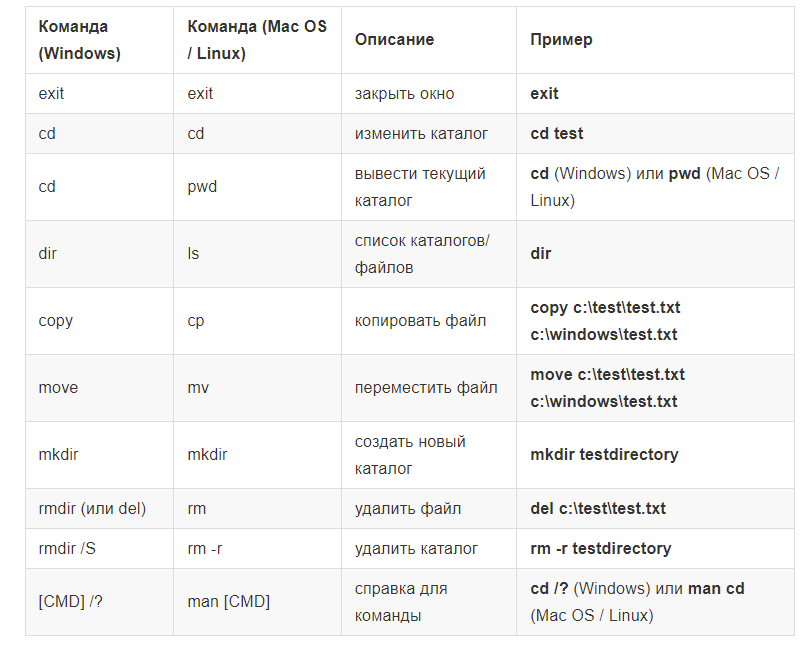

## Sublime Text

Зачем устанавливать отдельную программу для редактирования кода, если можно использовать Word или Notepad?

Во-первых, код должен должен храниться в виде простого текста, а проблема таких программ, как Word или Textedit в том, что они не сохраняют файлы в этом виде, а используют "обогащённый" текст (с форматированием и шрифтами), например, RTF (Rich Text Format).

Вторая причина в том, что специализированные редакторы предоставляют множество полезных для программирования возможностей, таких как цветная подсветка кода в зависимости от его смысла и автоматически закрывающиеся кавычки.

## Jupyter notebook - ANACONDA и WSL

https://pythonru.com/baza-znanij/kak-ustanovit-anaconda-na-windows

```python
wsl.exe --install
```

```python
sudo apt update
sudo apt upgrade
```

```python
sudo apt install python3-pip python3-dev
```

```python
sudo -H pip3 install --upgrade pip
sudo -H pip3 install virtualenv
```

```python
mkdir env
cd env
```

```python
virtualenv env
```

```python
source env/bin/activate
```

```python
pip install jupyter
```

```python
jupyter notebook
```

A few things before we start:

Автор тетрадки: Воробьев Даниил @herrenot Использовались очевидные заимствования отовсюду подряд, материал никак не претендует на уникальность. Однако, любые опечатки и неточности, конечно же, исключительно на моей совести Тут подразумевается Python3.7 и 3.8, скорее всего что-то не будет работать с более ранними версиями Я мало пишу на русском. Замечания про опечатки, отсутствующие запятые и несогласованные предложения приветствуются

Тут можно писать комментарии в языке Markdown, это такая разметка.

Среда называется jupyter notebook. Мы подробно про неё поговорим попозже

[figure not shown]

## Типы данных (базовые)

```
Базовых типов в питоне немного.
Это str, float, int, complex, boolean. Булевый самый простой и с ним можно использовать всякие операции
```

```
Python – язык со строгой динамической типизацией.
Т.е. тип используемой переменной трактуется в зависимости от значения, при этом не допускается неявное преобразование (например, сложение строки и числа).
```

### int

INT - это просто целые числа. Вы можете складывать (+), вычитать (-), умножать (*) и делить (/) целые числа в Python.

```python
2+2
```

```
4
```

```python
2*3
```

```
6
```

```python
12345678 * 987654328765432318765
```

```
12193262318244164938266047670
```

```python
2**2
```

```
4
```

```python
10 - 5
```

```
5
```

```python
3 + 5 * 4
```

```
23
```

```python
3 + 5 * 4
```

```
23
```

```python
40 // 8
```

```
5
```

```python
40 / 8
```

```
5.0
```

```python
42 // 8
```

```
5
```

```python
42 % 8
```

```
2
```

```python
239 % 10
```

```
9
```

```python
- (42)
```

```
-42
```

```python
+ (42)
```

```
42
```

```python
+-+42
```

```
-42
```

### Сообщения об ошибках

```python
-*42
```

```
  File "<ipython-input-13-761874de80cf>", line 1
    -*42
     ^
SyntaxError: invalid syntax
```

```python
+-+42
* 23
```

```
  File "<ipython-input-14-7b97d031da85>", line 2
    * 23
    ^
SyntaxError: can't use starred expression here
```

```python
5 // 0
```

```
---------------------------------------------------------------------------
ZeroDivisionError                         Traceback (most recent call last)
<ipython-input-15-e6530c2158eb> in <module>
----> 1 5 // 0

ZeroDivisionError: integer division or modulo by zero
```

### Числа с плавающей точкой . FLOAT

Python называет любое число с десятичной точкой float. Этот термин используется в большинстве языков программирования и относится к тому факту, что десятичная точка может стоять в любой позиции числа. Каждый язык программирования должен быть тщательно разработан для правильного управления десятичными числами, чтобы числа вели себя соответствующим образом независимо от того, где находится десятичная точка.

По большей части вы можете использовать десятичные дроби, не беспокоясь о том, как они себя ведут. Просто введите числа, которые вы хотите использовать, и Python, скорее всего, сделает то, что вы ожидаете:

```python
0.5 + 0.3
```

```
0.8
```

```python
5 / 2
```

```
2.5
```

```python
5 // 2
```

```
2
```

```python
1 / 3
```

```
0.3333333333333333
```

Но имейте в виду, что иногда вы можете получить в своем ответе произвольное количество десятичных знаков:

```python
0.3 + 0.3 + 0.3
```

```
0.8999999999999999
```

[figure not shown]

Питоновский float это аналог сишного double, т.е. формат числа с плавающей точкой. Упомянутая погрешность это не погрешность питона или другого языка, это проблема всех типов форматов хранения числа с плавающей точкой. Просто некоторые программы автоматически округляют хвосты и это не заметно. Используйте round(x,n) и будет вам счастье. А еще в питоне есть decimal(формат с фиксированным числом знаков после запятой) и fractions (число задается в виде дроби)

```python
0.3 + 0.3 + 0.3 == 0.9
```

```
False
```

```python
9 ** 0.5
```

```
3.0
```

```python
5e-1
```

```
0.5
```

```python
1234e2
```

```
123400.0
```

```python
5+5
```

```
10
```

```python
float(5) +5
```

```
10.0
```

```python
int(5.0) +5
```

```
10
```

```python
int(5.0) +5.0
```

```
10.0
```

```python
7/3
```

```
2.3333333333333335
```

```python
type(7)
```

```
int
```

```python
type(7.0)
```

```
float
```

```python
type(True)
```

```
bool
```

```python
type(true)
```

```
---------------------------------------------------------------------------
NameError                                 Traceback (most recent call last)
<ipython-input-29-6f4d8242c3d0> in <module>
----> 1 type(true)

NameError: name 'true' is not defined
```

[figure not shown]

## ПРАКТИКА

```python
1) Найдите остаток от деления 77 на 2
```

```python
2) Узнайте четное ли число 22
```

```python
3) Посчитайте 86 в степени 7
```

```python
4) Найдите квадратный корень из 3686400
```

## ДЗ

##### Установить:

```
1) Редактор кода (например sublime)
2) jupyter notebook (wsl или анаконда)
```